# iLab 2

Eric Stevens

10/11/2018

## Environment Setup

```r
library(tidyverse) # all the good stuff
library(readxl) # for reading in xlsx files
library(janitor) # for clean_names
library(knitr) # for kable
library(moderndive) # for getting tables
library(corrr) # for correlation matrix
library(skimr) # for skim
```

```r
library(GGally) # for ggpairs
library(broom) # for pulling out model results
```

## The Data

#### Retrieve the data:

```r
# install.packages("rdryad")
# install.packages("purrr")
library(rdryad) # to access the API
library(readxl) # to read in the xlsx file
library(purrr) # for 1 function: pluck!
path_to_xlsx <- dryad_fetch(dryad_files(doi = '10.5061/dryad.7763s/1')) %>%
  pluck(1)
vitd <- read_xlsx(path_to_xlsx, sheet = 1)
```

#### Clean and view the data:

```r
library(janitor)
vitd <- vitd %>%
  clean_names()
glimpse(vitd)
```

```
## Observations: 537
## Variables: 19
## $ id          <dbl> 101, 102, 104, 105, 106, 107, 108, 110, 112, 113, ...
## $ sex         <chr> "F", "F", "F", "F", "M", "M", "M", "F", "F", "F", ...
## $ ageyears    <dbl> 7.749487, 7.040383, 7.289528, 7.251198, 6.845995, ...
## $ height      <dbl> 121.80, 120.40, 117.00, 115.60, 113.30, 121.60, 12...
## $ weight      <dbl> 20.0, 18.1, 19.6, 19.3, 17.0, 23.8, 24.1, 23.1, 22...
## $ bmi         <dbl> 13.48141, 12.48606, 14.31807, 14.44248, 13.24308, ...
## $ zwfa        <dbl> -1.29, -1.47, -1.09, -1.17, -2.18, -0.28, -0.07, -...
## $ underweight <chr> "not underweight", "not underweight", "not underwe...
## $ zbfa        <dbl> -1.45, -2.24, -0.75, -0.65, -1.88, 0.28, -0.48, -1...
## $ wasted      <chr> "not wasted", "wasted", "not wasted", "not wasted"...
## $ zhfa        <dbl> -0.58, -0.12, -0.98, -1.20, -1.45, -0.77, 0.34, -0...
## $ stunted     <chr> "not stunted", "not stunted", "not stunted", "not ...
## $ period      <dbl> 0, 0, 0, 0, 0, 0, 0, 0, 0, 0, 0, 0, 0, 0, 0, 0, 0,...
## $ ifyeswhen   <chr> NA, NA, NA, NA, NA, NA, NA, NA, NA, NA, NA, NA, NA...
## $ school      <dbl> 1, 1, 1, 1, 1, 1, 1, 1, 1, 1, 1, 1, 1, 1, 1, 1, 1,...
## $ baseline_ca <dbl> NA, NA, NA, 57.6876, NA, NA, 290.4152, 131.2554, N...
## $ pth         <dbl> 66.7, 55.1, 29.5, 48.9, 20.7, 23.9, 23.4, 24.7, 33...
## $ x25d        <dbl> 72.2, 73.4, 64.6, 73.6, 88.5, 85.8, NA, 75.2, 82.9...
## $ x125d       <dbl> 265, 144, 320, 245, 251, 206, 200, 205, 254, 223, ...
```

#### Code book

```r
codebook <- read_xlsx(path_to_xlsx, sheet = 2)
lm_vars <- c("sex", "_zhfa", "ageyears", "_25D")
codebook %>%
  filter(Variable %in% lm_vars) %>%
  knitr::kable()
```

| Variable | Description | Unit or coding where applicable |
| --- | --- | --- |
| sex | Sex of child participant | F=female, M=male |
| ageyears | Age of child participant | YEARS |
| _zhfa | Height-for-age z-score | Standard deviation (SD) |
| _25D | Serum 25-hydroxyvitamin D concentrations | nmol/L |

## Exploratory Data Analysis

### Raw Data

First lets extract the raw data that is of interest to us and take a glimpse at the raw data.

```r
data <- select(vitd, id, sex, ageyears, zhfa, x25d)
glimpse(data)
```

```
## Observations: 537
## Variables: 5
## $ id       <dbl> 101, 102, 104, 105, 106, 107, 108, 110, 112, 113, 115...
## $ sex      <chr> "F", "F", "F", "F", "M", "M", "M", "F", "F", "F", "M"...
## $ ageyears <dbl> 7.749487, 7.040383, 7.289528, 7.251198, 6.845995, 7.7...
## $ zhfa     <dbl> -0.58, -0.12, -0.98, -1.20, -1.45, -0.77, 0.34, -0.33...
## $ x25d     <dbl> 72.2, 73.4, 64.6, 73.6, 88.5, 85.8, NA, 75.2, 82.9, 7...
```

### Summary Statistics

Now lets get the summary statistics for the data we have.

```r
skim(data)
```

```
## Skim summary statistics
##  n obs: 537
##  n variables: 5
##
## ── Variable type:character ─────────────────────────────────────────────────────
##  variable missing complete   n min max empty n_unique
##       sex       0      537 537   1   1     0        2
##
## ── Variable type:numeric ───────────────────────────────────────────────────────
##  variable missing complete   n   mean     sd     p0    p25    p50    p75
##  ageyears       0      537 537   9.89   1.69   6.16   8.38   9.95  11.26
##        id       0      537 537 585.8  293.24 101    329    610    836
##      x25d       8      529 537  74.31  15.39  36.1   64.3   73.6   84.3
##      zhfa       0      537 537  -0.98   0.84  -3.35  -1.57  -1     -0.36
##     p100     hist
##    14.03 ▁▇▇▇▇▇▅▁
##  1062    ▇▇▇▅▆▇▇▇
##   127    ▁▃▆▇▅▂▁▁
##     1.86 ▁▂▆▇▆▃▁▁
```

Now lets get the correlations between the numeric variables. Since ‘sex’ is categorical variable we will look at three different cases. First we will look at the correlations of all the data, then we will look at correlations among males, and finally we will look correlation among females.

##### All data correlation:

```r
data %>% select("ageyears", "zhfa", "x25d") %>% corrr::correlate()
```

```
##
## Correlation method: 'pearson'
## Missing treated using: 'pairwise.complete.obs'
```

```
## # A tibble: 3 x 4
##   rowname  ageyears     zhfa    x25d
##   <chr>       <dbl>    <dbl>   <dbl>
## 1 ageyears  NA       -0.0852  -0.173
## 2 zhfa      -0.0852  NA       -0.116
## 3 x25d      -0.173   -0.116   NA
```

From this we can that there is a slight negative correlation between the age of the child being observed and the amount of the vitamin serum. There is also a slight negative correlation between the height z score and and the amount of the vitamin serum.

Since we do have the one binary categorical variable (sex) it is worth splitting the data up and examining the subsets of the data individually to see if there is a drastic difference in correlation. If there is then a better model will be one that takes the category into account.

##### Male correlation:

```r
data %>% filter(sex == "M") %>%
  select("ageyears", "zhfa", "x25d") %>%
  corrr::correlate()
```

```
##
## Correlation method: 'pearson'
## Missing treated using: 'pairwise.complete.obs'
```

```
## # A tibble: 3 x 4
##   rowname   ageyears     zhfa      x25d
##   <chr>        <dbl>    <dbl>     <dbl>
## 1 ageyears  NA        -0.0702  -0.00857
## 2 zhfa      -0.0702   NA       -0.0952
## 3 x25d      -0.00857  -0.0952  NA
```

##### Female correleation:

```r
data %>% filter(sex == "F") %>%
  select("ageyears", "zhfa", "x25d") %>%
  corrr::correlate()
```

```
##
## Correlation method: 'pearson'
## Missing treated using: 'pairwise.complete.obs'
```

```
## # A tibble: 3 x 4
##   rowname  ageyears     zhfa     x25d
##   <chr>       <dbl>    <dbl>    <dbl>
## 1 ageyears  NA       -0.0955  -0.398
## 2 zhfa      -0.0955  NA       -0.0749
## 3 x25d      -0.398   -0.0749  NA
```

### Visualizations

Now lets look at some data visualizations to help us better understand the data set.

First we will create a scatter plot that shows the presence of the serum by sex. A jitter is used to allow us to quantify the number of observations.

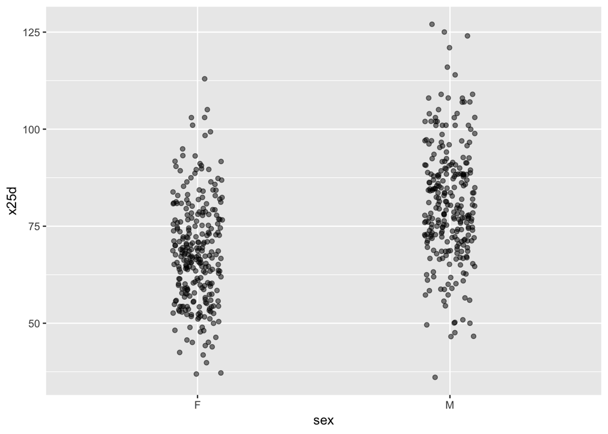

```r
ggplot(data, aes(x = sex, y = x25d)) +
  geom_jitter(position = position_jitter(width = 0.1), alpha = 0.5)
```

It seems that the data set has about an equal number of males and females. it is worth noting that the female serum level appears to be noticeable lower than male levels.

Now lets get and idea of the age of our observees. To do this we will use a histogram. We will also color code the histogram by sex to confirm the gender makeup of the observees.

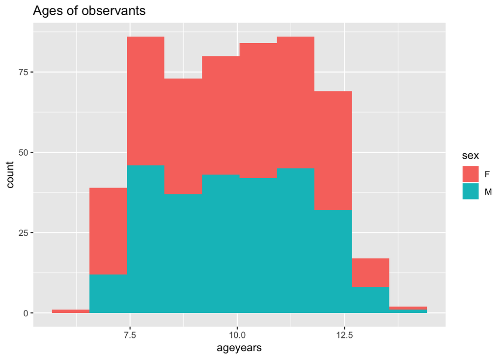

```r
ggplot(data,aes(x=ageyears, fill=sex)) +
  geom_histogram(bins = 10) +
  ggtitle("Ages of observants")
```

We can see that there is a pretty consistent age distribution from about age 7 to age 13. Can confirm that there are about the same number of male and female subjects in the data set.

Now lets look at some density plots to see how much of a spread there is in the data.

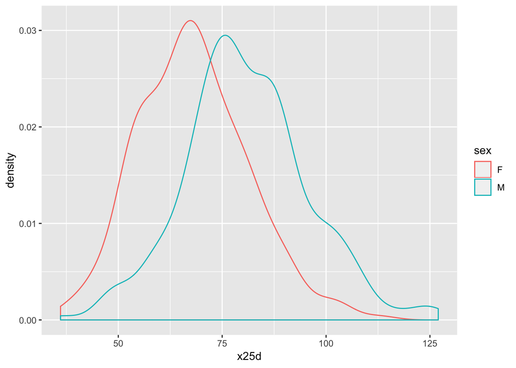

```r
ggplot(data, aes(x25d, colour=sex, group=sex)) + geom_density()
```

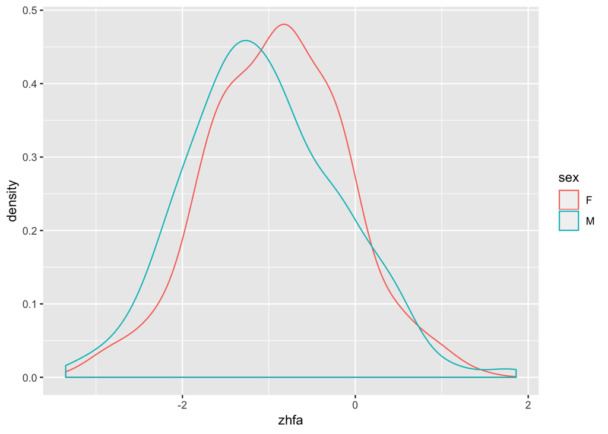

```r
ggplot(data, aes(zhfa, colour=sex, group=sex)) + geom_density()
```

form this we can see that there is a basically a normal distribution of for both male and female both in vitamin serum levels and in height. There is definitely a slight skew in the female data towards less vitamin serum compared to the males. The ‘zhfa’ plot shows us that both males and females are around a standard deviations shorter than the average height for their respective ages.

### Questions

##### 1. How many variables/columns?

```r
ncol(data)
```

```
## [1] 5
```

```r
colnames(data)
```

```
## [1] "id"       "sex"      "ageyears" "zhfa"     "x25d"
```

##### 2. How many rows/observations?

```r
nrow(data)
```

```
## [1] 537
```

There are 537 observations.

##### 3. Which variables are numbers?

```r
data %>% select_if(is.numeric) %>% colnames()
```

```
## [1] "id"       "ageyears" "zhfa"     "x25d"
```

##### 4. Which variables are catigorical?

```r
data %>% select_if(is.character) %>% colnames()
```

```
## [1] "sex"
```

Only the ‘sex’ variable is categorical.

##### 5. There is one row per person.

## Regression Model

Our goal is to come up with a model that will predict the amount of the vitamin serum in the observee based on their age, sex, and relative height. Lets first fit a model that ignores gender, since it is the only categorical variable.

```r
vit25d_model <- lm(x25d ~ ageyears + zhfa, data )
get_regression_table(vit25d_model)
```

```
## # A tibble: 3 x 7
##   term      estimate std_error statistic p_value lower_ci upper_ci
##   <chr>        <dbl>     <dbl>     <dbl>   <dbl>    <dbl>    <dbl>
## 1 intercept    88.5      3.94      22.5    0        80.8    96.3
## 2 ageyears     -1.67     0.391     -4.28   0        -2.44   -0.905
## 3 zhfa         -2.35     0.778     -3.02   0.003    -3.88   -0.822
```

This table shows us an intercept of 88.5 nmol/L. This means that if someone was of average height and 0 years old, this would be the expected level of the vitamin serum in their body. The age coefficient is -1.7, meaning that for every year we go up in age there will be a corresponding drop in the vitamin serum of 1.7 nmol/L. This can be visualized as follows:

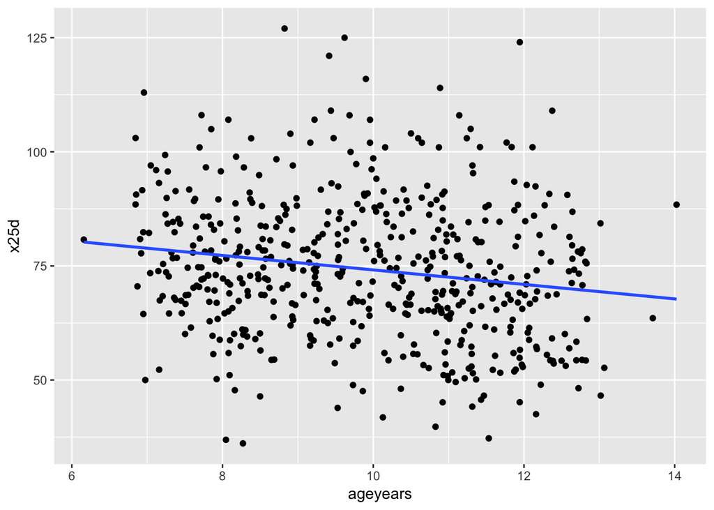

```r
select(data, ageyears, x25d) %>%
ggplot( aes(x = ageyears, y = x25d)) +
  geom_jitter() +
  #labs(x = "Age", y = "Teaching Score", color = "Gender") +
  geom_smooth(method = "lm", se = FALSE)
```

we see that over the entire graph the line drops about 13 nmol/L and as it ascends about 8 years. 13/8 is roughly the 1.7 we calculated in the last block. Also notice that if the x axis was to include the 0 point the line would hit the x=0 axis at roughly 88 nmol/L

Lets break the model up into the separate sexes, since we have already seen that there are differences between the sexes and their correlations.

Lets again look at the age regression:

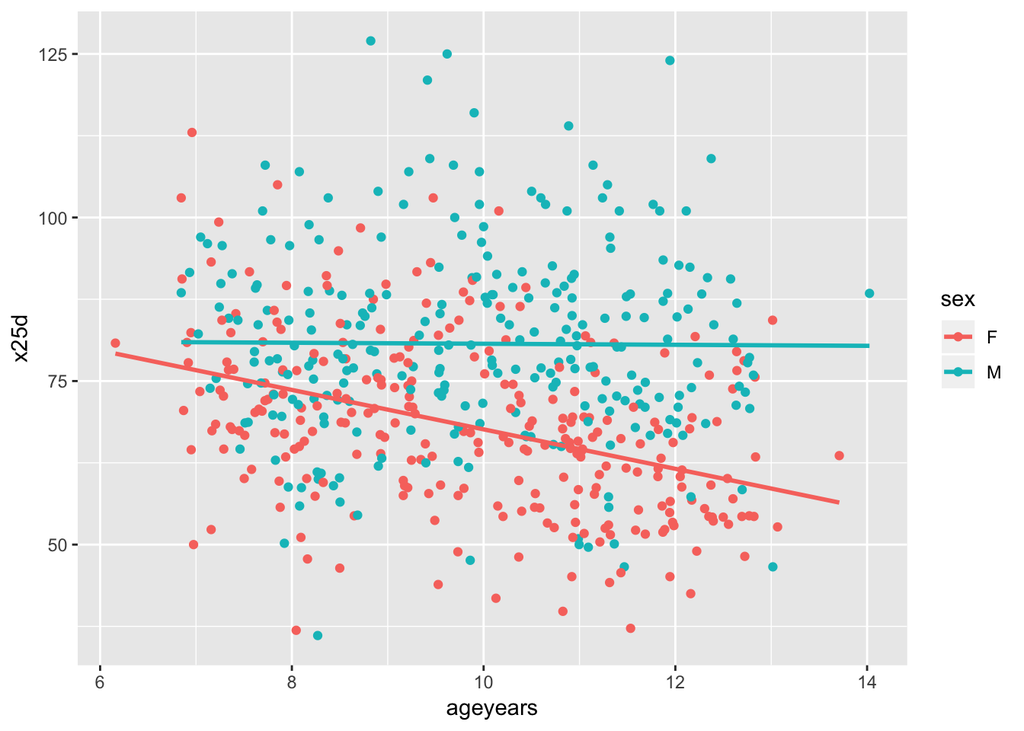

```r
ggplot(data, aes(x = ageyears, y = x25d, color = sex)) +
  geom_point() +
  #labs(x = "Age", y = "Teaching Score", color = "Gender") +
  geom_smooth(method = "lm", se = FALSE)
```

As could have been predicted from our correlation table, we can see that the male observees are maintaining there vitamin serum levels over time whereas the females have a sharp drop over time.

Lets also look at how the height for age z scores correlate with serum levels:

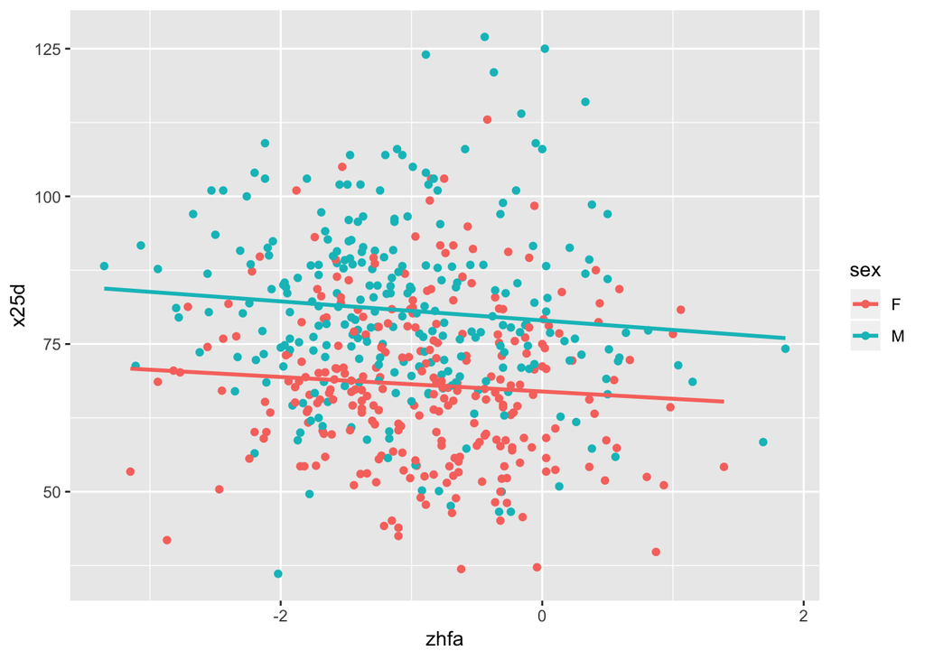

```r
ggplot(data, aes(x = zhfa, y = x25d, color = sex)) +
  geom_point()+
  #labs(x = "Age", y = "Teaching Score", color = "Gender") +
  geom_smooth(method = "lm", se = FALSE)
```

Here the slopes of the lines are almost identical. The slight downward slope indicates that the shorter one is relative to the average for their age the more serum they will have in there system. The difference in y intercepts here indicates that males are on average likely to have higher levels of serum regardless of age.

Lets build a multi regression interaction model that accounts for all the combinations of effects that could be effecting the outcome of these test. This will be the linear model that has the most degrees of freedom. This is done by allowing coefficients that will adjust the intercept and slope of the model based on sex.

```r
vit25d_model_interaction <- lm(x25d ~ ageyears * sex + zhfa * sex, data )
get_regression_table(vit25d_model_interaction)
```

```
## # A tibble: 6 x 7
##   term          estimate std_error statistic p_value lower_ci upper_ci
##   <chr>            <dbl>     <dbl>     <dbl>   <dbl>    <dbl>    <dbl>
## 1 intercept        96.9      4.78     20.3     0        87.5   106.
## 2 ageyears         -3.10     0.478    -6.48    0        -4.03   -2.16
## 3 sexM            -16.7      7.10     -2.35    0.019   -30.6    -2.71
## 4 zhfa             -1.85     1.03     -1.79    0.074    -3.88    0.178
## 5 ageyears:sexM     2.97     0.705     4.22    0         1.59    4.36
## 6 sexM:zhfa         0.23     1.41      0.164   0.87     -2.53    2.99
```

Lets look at the results of this model more closely.

##### Intercept

The intercept of the model is 96.88. This means that at average height and at age 0 the a female is likely to have 96.88 nmol/L of the vitamin serum in her body. This only applies to the female because of the sex dimension we added to the model. This will be explained shortly.

##### ‘ageyears’ Coefficent

The ageyears is modeled to be roughly -3. This means that for every year in age a female grows up her vitamin serum levels will drop by 3 nmol/L.

##### ‘sexM’ Coefficent

This coefficient allows for constant difference between male and female models and explains the reason for the only female intercept referred to above. The value of -16.67 means that whenever the data being modeled is a male, there will be a constant of 16.67 subtracted form the model described above. This is what allows the first intercept to be different for male. For a male of average height at age 0 the expected serum level will be $ 96.88 - 16.67 nmol/L $.

##### ‘ageyears:sexM’ Coefficent

This coefficient allows the slope of the model to be different for males than it is for females. The slope for males will be the sum of the ‘ageyears’ coefficient and the ‘ageyears:sexM’ coefficient. In other words, for each year that male observees grow the will have (-3.10 + 2.97) less nmol/L of serum in their systems.

##### ‘zhfa’ Coefficent

With a value of -1.85, the coefficient implies that for every standard deviation taller than the average for their age they are, women will have 1.85 fewer nmol/L of the serum in their bodies.

##### ‘sexM:zhfa’

In the same way the ‘ageyears:sexM’ allowed the slope of the male age line to differ from the female line, this one allows the the male zhfa line to differ from the females. The +0.23 coefficient is suspicious because this means that the correlation for males will be (-1.85 + 0.23) fewer nmol/L of serum per standard deviation in height. This implies that we have a less steep correlation for males than females on the zhfa, which is the appears to be the opposite of what we saw in the x25d/zhfa graph, where the male line seemed to be steeper. This degree of freedom may be resulting in over fitting.

To answer the question about the claims made in the paper about a 19% higher male vit25 rate at age 9.9, which we will assume is the mean age of the data, we need to create a slightly different model that mean zeros on age. The other claim was that male levels stay the same as female rates drop. Lets look at the regression table:

```r
vit25d_model_age_sex <- lm(x25d ~ scale(ageyears)*sex, data )
get_regression_table(vit25d_model_age_sex)
```

```
## # A tibble: 4 x 7
##   term              estimate std_error statistic p_value lower_ci upper_ci
##   <chr>                <dbl>     <dbl>     <dbl>   <dbl>    <dbl>    <dbl>
## 1 intercept            68.0      0.829     82.0        0    66.3     69.6
## 2 scale(ageyears)      -5.09     0.805     -6.32       0    -6.67    -3.50
## 3 sexM                 12.8      1.18      10.8        0    10.4     15.1
## 4 scale(ageyears):…     4.95     1.19       4.16       0     2.62     7.29
```

As we can see we have the same result from this table. The intercept ~68 is the vitamin levels of females at age 9.9. The intercept plus the sexM is where males are at the same age. 13/68 = 0.19 or 19%. The ageyears coefficient shows that women drop off with age while men stay the same.

## Residual Analysis

Now lets examine how well our model actual fit the data.

```r
regression_points <- get_regression_points(vit25d_model_interaction)
regression_points
```

```
## # A tibble: 529 x 7
##       ID  x25d ageyears sex     zhfa x25d_hat residual
##    <int> <dbl>    <dbl> <chr>  <dbl>    <dbl>    <dbl>
##  1     1  72.2     7.75 F     -0.580     74.0    -1.76
##  2     2  73.4     7.04 F     -0.12      75.3    -1.91
##  3     3  64.6     7.29 F     -0.98      76.1   -11.5
##  4     4  73.6     7.25 F     -1.2       76.7    -3.06
##  5     5  88.5     6.85 M     -1.45      81.7     6.78
##  6     6  85.8     7.74 M     -0.77      80.5     5.30
##  7     7  75.2     8.78 F     -0.33      70.3     4.88
##  8     8  82.9     7.89 F     -0.36      73.1     9.77
##  9     9  70.2     7.62 F     -1.66      76.4    -6.18
## 10    10  84.9     8.76 M     -1.32      81.3     3.63
## # ... with 519 more rows
```

There are very large residuals that correspond to serum level differences to the point that it leads me to believe that the model is useless in terms of predicting what someones serum levels will be. The best this model can accomplish is discovering weak trends. This is visualized below.

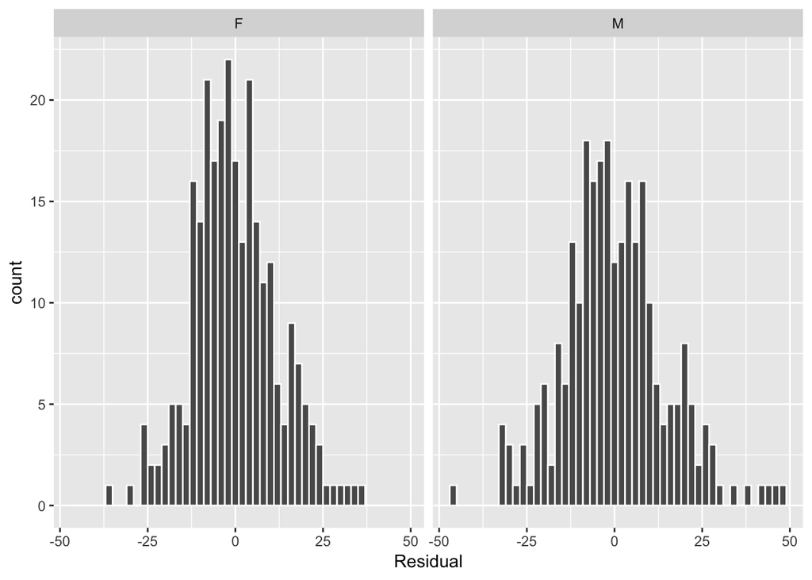

```r
ggplot(regression_points, aes(x = residual)) +
  geom_histogram(binwidth = 2, color = "white") +
  labs(x = "Residual") +
  facet_wrap(~sex)
```

The normal distribution of the data implies that there is some correlation, but again, the standard deviations of this data are huge in terms of amount of serum.

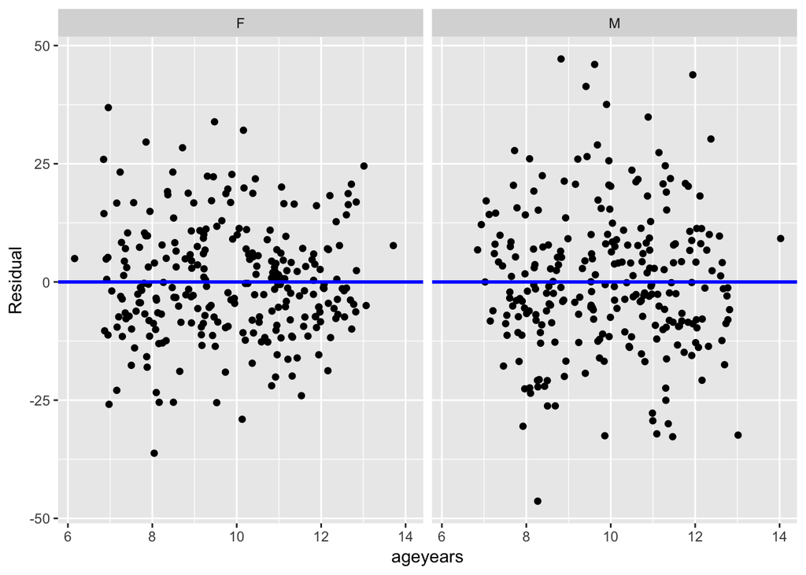

```r
ggplot(regression_points, aes(x = ageyears, y = residual)) +
  geom_point() +
  labs(x = "ageyears", y = "Residual") +
  geom_hline(yintercept = 0, col = "blue", size = 1) +
  facet_wrap(~ sex)
```

There does not appear to be any symmetric pattern in the residual plots, a good sign that our model is the best it could be.

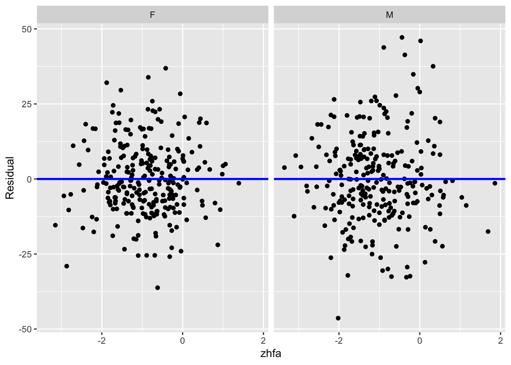

```r
ggplot(regression_points, aes(x = zhfa, y = residual)) +
  geom_point() +
  labs(x = "zhfa", y = "Residual") +
  geom_hline(yintercept = 0, col = "blue", size = 1) +
  facet_wrap(~ sex)
```

## Outlier Analysis

```r
vit25_diag <- broom::augment(vit25d_model_interaction, data) %>%
  mutate(.ext.resid = rstudent(vit25d_model_interaction))
glimpse(vit25_diag)
```

```
## Observations: 529
## Variables: 13
## $ id         <dbl> 101, 102, 104, 105, 106, 107, 110, 112, 113, 115, 1...
## $ sex        <chr> "F", "F", "F", "F", "M", "M", "F", "F", "F", "M", "...
## $ ageyears   <dbl> 7.749487, 7.040383, 7.289528, 7.251198, 6.845995, 7...
## $ zhfa       <dbl> -0.58, -0.12, -0.98, -1.20, -1.45, -0.77, -0.33, -0...
## $ x25d       <dbl> 72.2, 73.4, 64.6, 73.6, 88.5, 85.8, 75.2, 82.9, 70....
## $ .fitted    <dbl> 73.96483, 75.30754, 76.12948, 76.65566, 81.71632, 8...
## $ .se.fit    <dbl> 1.3175609, 1.7134031, 1.4822005, 1.5430945, 1.85378...
## $ .resid     <dbl> -1.764833, -1.907542, -11.529482, -3.055659, 6.7836...
## $ .hat       <dbl> 0.009506345, 0.016076492, 0.012030567, 0.013039389,...
## $ .sigma     <dbl> 13.52609, 13.52605, 13.51678, 13.52565, 13.52299, 1...
## $ .cooksd    <dbl> 2.754473e-05, 5.514900e-05, 1.495339e-03, 1.140744e...
## $ .std.resid <dbl> -0.1312242, -0.1423080, -0.8583692, -0.2276098, 0.5...
## $ .ext.resid <dbl> -0.1311008, -0.1421747, -0.8581529, -0.2274034, 0.5...
```

```r
high_hat <- vit25_diag %>%
              select(ageyears, zhfa, x25d,.hat) %>%
              filter(.hat > 4*mean(.hat))

high_hat
```

```
## # A tibble: 3 x 4
##   ageyears  zhfa  x25d   .hat
##      <dbl> <dbl> <dbl>  <dbl>
## 1     12.5  1.39  54.2 0.0464
## 2     12.7  1.69  58.4 0.0550
## 3     12.7  1.86  74.2 0.0596
```

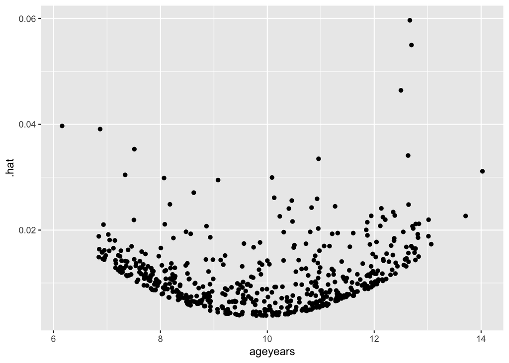

```r
vit25_diag %>%
  ggplot(aes(x=ageyears, y=.hat)) + geom_point()
```

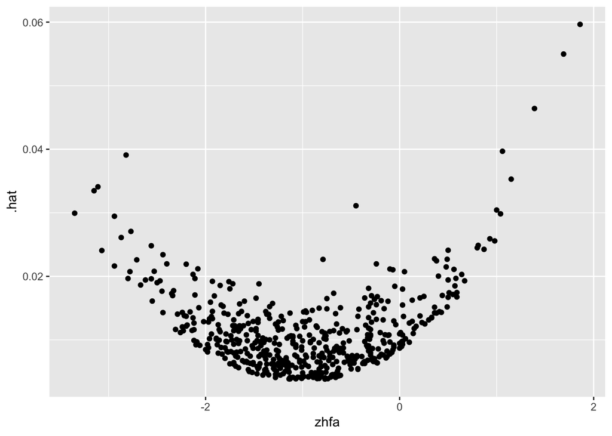

```r
vit25_diag %>%
  ggplot(aes(x=zhfa, y=.hat)) + geom_point()
```

```r
high_dis <- vit25_diag %>%
  select(ageyears, zhfa, x25d, .std.resid, .ext.resid) %>%
  arrange(desc(.ext.resid)) %>%
  slice(1:5)

high_dis
```

```
## # A tibble: 5 x 5
##   ageyears  zhfa  x25d .std.resid .ext.resid
##      <dbl> <dbl> <dbl>      <dbl>      <dbl>
## 1     8.82 -0.44   127       3.50       3.54
## 2     9.62  0.02   125       3.42       3.46
## 3    11.9  -0.89   124       3.26       3.29
## 4     9.41 -0.37   121       3.07       3.10
## 5     9.90  0.33   116       2.80       2.82
```

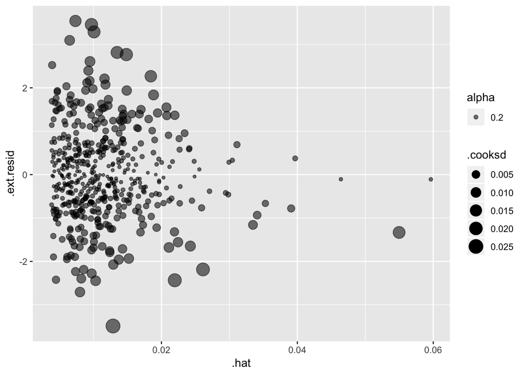

```r
ggplot(vit25_diag, aes(x=.hat, y=.ext.resid, alpha=.2, size=.cooksd)) + geom_point()
```

By looking at the original plots I would expect there to be around 5% high discrepancy. From the graph above we can see that there are point that have high leverage and there are points that have high discrepancy but there does not seem to be many points that have both. The influence on the model is high for many of the points, but it seems to be distributed fairly evenly. I think that this data is very noisy and that is the reason for the high levels of influence. Due to the noise in this data I would not remove any of the data points. I think this model is a very rough fit for both the males and the females and cannot say which one is better suited to the model.

## Sum of Squares

The following code makes a table of the different sum of squares. This consists of total sum of squares, residual sum of squares, and model sum of squares.

```r
vitd_ss <- regression_points %>%
  summarise(total_ss = sum((x25d - mean(x25d))^2),
            resid_ss = sum((x25d_hat - x25d)^2),
            model_ss = sum((x25d_hat - mean(x25d_hat))^2))
vitd_ss
```

```
## # A tibble: 1 x 3
##   total_ss resid_ss model_ss
##      <dbl>    <dbl>    <dbl>
## 1  125063.   95506.   29558.
```

We can see that the total sum of squares is 125,063.5. Lets prove that the sum of the residual sum squares and the model sum squares are equal to the total sum squares.

```r
vitd_ss %>% mutate(risid_plus_model = resid_ss + model_ss)
```

```
## # A tibble: 1 x 4
##   total_ss resid_ss model_ss risid_plus_model
##      <dbl>    <dbl>    <dbl>            <dbl>
## 1  125063.   95506.   29558.          125063.
```

We can see that the new column we added to the table is equal to total_ss value other than what is presumably a floating point rounding error.

Now lets show that the variance of the vitamin serum levels in the data is equal to the total sum of squares divided by the number of data points minus 1.

The variance is calculated as follows.

```r
var(regression_points["x25d"])
```

```
##          x25d
## x25d 236.8626
```

We see that the variance of the vitamin serum points is 236.86

Now lets calculate the total sum of squares divided by the number of data points minus 1.

```r
vitd_ss %>% mutate(total_over_nminusone = total_ss / (nrow(regression_points) - 1))
```

```
## # A tibble: 1 x 4
##   total_ss resid_ss model_ss total_over_nminusone
##      <dbl>    <dbl>    <dbl>                <dbl>
## 1  125063.   95506.   29558.                 237.
```

Exactly 236.86, so we have proven this clause.

Finally lets show that the $ R^2 $ of the data is the same as the model ss divided by the total ss.

To get the $R^2$ value we do the following.

```r
broom::glance(vit25d_model_interaction)["r.squared"]
```

```
## # A tibble: 1 x 1
##   r.squared
##       <dbl>
## 1     0.236
```

So $R^2 = 0.23634$.

Now lets calculate $\frac{model ss}{total ss}$

```r
mutate(vitd_ss, model_ss/total_ss)
```

```
## # A tibble: 1 x 4
##   total_ss resid_ss model_ss `model_ss/total_ss`
##      <dbl>    <dbl>    <dbl>               <dbl>
## 1  125063.   95506.   29558.               0.236
```

We can see that $R^2 = \frac{model ss}{total ss}$

## NULL Model

In the null model the only thing that is taken into consideration is the intercept. In other words its a flat model.

```r
vitd_complete <- vitd %>%
  drop_na(x25d, sex, ageyears, zhfa)
int_mod <- lm(x25d ~ 1, data = vitd_complete)
get_regression_table(int_mod)
```

```
## # A tibble: 1 x 7
##   term      estimate std_error statistic p_value lower_ci upper_ci
##   <chr>        <dbl>     <dbl>     <dbl>   <dbl>    <dbl>    <dbl>
## 1 intercept     74.3     0.669      111.       0     73.0     75.6
```

We can see that the intercept is 74.307. This is the same number we came across as the mean of the vitamin serum x25d in our initial data analysis.

Lets compare this model to our multi-regression model.

```r
anova(int_mod, vit25d_model_interaction)
```

```
## Analysis of Variance Table
##
## Model 1: x25d ~ 1
## Model 2: x25d ~ ageyears * sex + zhfa * sex
##   Res.Df    RSS Df Sum of Sq      F    Pr(>F)
## 1    528 125063
## 2    523  95506  5     29558 32.372 < 2.2e-16 ***
## ---
## Signif. codes:  0 '***' 0.001 '**' 0.01 '*' 0.05 '.' 0.1 ' ' 1
```

The RSS in line one corresponds to the total sum squared in the multi- regression model. The RSS in line two is the residual sum squared in the multi-regression model. The sum squared is equal to the models sum squared of the multi-regression model.

The difference between lm(y ~ x + z) versus lm(y ~ 1) is the degrees of freedom in which the model can bend to the observations. lm(y ~ 1) has no degrees of freedom, and can only make predictions based on the value of the serum levels themselves; hence the point mean value model. The multi- regression model, lm(y ~ x + z), has two degrees of freedom it can move in and will result in 3 dimensional plane of of predicted values.

## Replicate a Plot

The plot form the paper is obviously not the raw data. In the figure they present the minimum appears to be around 54 nmol/L and the maximum appears to be around 81. This does not match our EDA observations at all, where the minimum was below 40 nmol/L and the max was over 125 nmol/L.

The graph we created using the observation data in the EDA will be reproduced here:

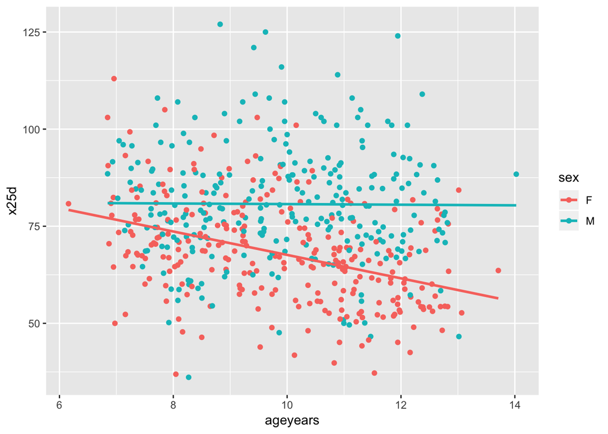

```r
ggplot(data, aes(x = ageyears, y = x25d, color = sex)) +
  geom_point() +
  #labs(x = "Age", y = "Teaching Score", color = "Gender") +
  geom_smooth(method = "lm", se = FALSE)
```

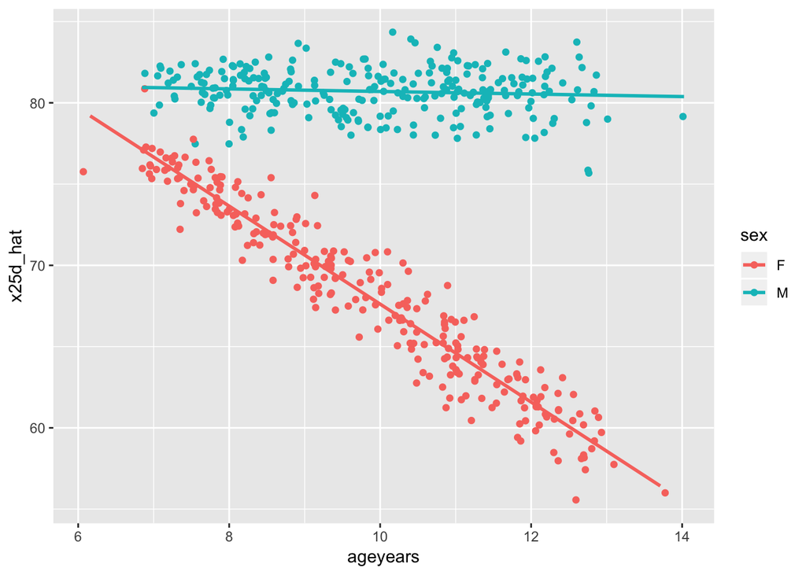

```r
ggplot(regression_points, aes(x = ageyears, y = x25d_hat, color = sex)) +
  geom_jitter(width = 0.1, height = 0.1) +
  #labs(x = "Age", y = "Teaching Score", color = "Gender") +
  geom_smooth(method = "lm", se = FALSE)
```

I cant imagine why this would be done in a research environment. This is totally misleading. To me, there appears to be no purpose to jittering the model. You can just show the regression lines themselves if you want to see what the model is.

## Process

To to this project I read the chapter from the course text. I followed techniques and procedures from the multi-regression chapter. All of the functions I used came from that chapter and from the assignment itself. I found the last section challenging because my goal to replicate the graphic found in the assignment, and it did not immediately come to my mind to jitter the model. I also believe that I may have added an extra degree of freedom to my model that was not a requirement of the assignment.

In general, the most difficult part of these assignments are approximating how much of this is a creative process that I should be doing on my own and and weighing that against how the assignments will be graded in terms of adhering to a strict procedure. This should become less of a problem once the first grades come back and I can see where I lost points.